# Data Preprocess on PISA 2018 data

## empty the environment

```r
rm(list = ls())
```

Set the working directory the same as where this Rmd file is located.

## read the raw data

```r
full_student_data_2018<-readRDS(file = "./data/raw/full_student_data_2018.Rds")
countrycode<-readRDS(file = "./data/raw/countrycode.Rds")
school_2018<-readRDS(file = "./data/raw/school_2018.Rds")
```

## select data from Austrilia(AUS), Canada(CAN),United Kingdom(GBR)

Due to the computation time consuming, we are not able to do analysis to the whole PISA 2018 data. Therefore, we select three countries(AUS/CAN/GBR). all of them are developed countries from different continent while sharing similar culture background.

ChatGPT suggest justifying the selection based on the following points:

1. Shared Cultural and Educational Contexts: Australia, the United Kingdom, and Canada share similarities in language (predominantly English-speaking) and educational philosophies, providing a more coherent basis for comparative analysis.
2. Economic Comparability: These countries are high-income economies with well-established educational systems, making them suitable for examining variations within a comparable socioeconomic context.

Geographical Diversity within Similar Systems: Although these countries share similarities, their geographical dispersion allows exploration of how localized factors (e.g., regional policies or demographics) influence educational outcomes.

3. Participation and Data Completeness: These countries often have high participation rates and comprehensive data coverage in PISA assessments, ensuring robust and reliable datasets for analysis.
4. Relevance to Policy Implications: By focusing on these countries, the analysis can provide insights that are relevant to English-speaking educational systems, which may guide specific policy recommendations or initiatives.

This subset allows you to strike a balance between manageable scope and meaningful cross-country comparisons.

```r
# Load necessary libraries
library(tidyverse)
# Filter data for Australia, United Kingdom, and Canada
selected_countries <- c("AUS", "GBR", "CAN")

# Preprocess the data
selected_countries_student_data_2018 <- full_student_data_2018 %>%
  # Filter for selected countries
  filter(country %in% selected_countries) %>%
  # Select relevant columns
  select(
    country,
    school_id,
    student_id,
    gender,
    mother_educ,
    father_educ,
    computer,
    internet,
    math,
    read,
    science,
    stu_wgt
  )
```

```r
head(selected_countries_student_data_2018)
```

```
## # A tibble: 6 × 12
##   country school_id student_id gender mother_educ father_educ computer internet
##   <fct>   <fct>     <fct>      <fct>  <fct>       <fct>       <fct>    <fct>
## 1 AUS     3600001   3600716    male   ISCED 3A    ISCED 3A    yes      yes
## 2 AUS     3600001   3601281    female ISCED 1     ISCED 2     yes      yes
## 3 AUS     3600001   3603009    female ISCED 3A    ISCED 1     yes      yes
## 4 AUS     3600001   3604603    female ISCED 3A    ISCED 3A    yes      yes
## 5 AUS     3600001   3604881    female ISCED 2     ISCED 2     yes      yes
## 6 AUS     3600001   3605560    male   ISCED 3B, C ISCED 3A    yes      yes
## # ℹ 4 more variables: math <dbl>, read <dbl>, science <dbl>, stu_wgt <dbl>
```

```r
selected_countries_school_2018 <- school_2018 %>%
  # Filter for selected countries
  filter(country %in% selected_countries) %>%
  # Select relevant columns
  select(
    country,
    school_id,
    public_private
  )
```

```r
head(selected_countries_school_2018)
```

```
## # A tibble: 6 × 3
##   country school_id public_private
##   <fct>   <fct>     <fct>
## 1 AUS     3600001   <NA>
## 2 AUS     3600002   private
## 3 AUS     3600003   public
## 4 AUS     3600004   private
## 5 AUS     3600005   private
## 6 AUS     3600006   private
```

## Join public_private column in school dataset to student dataset

```r
# Perform a left join to add public_private to the student data
joined_data <- selected_countries_student_data_2018 %>%
  left_join(
    selected_countries_school_2018,
    by = c("country", "school_id")
  )

# Check the first few rows of the joined dataset
head(joined_data)
```

```
## # A tibble: 6 × 13
##   country school_id student_id gender mother_educ father_educ computer internet
##   <fct>   <fct>     <fct>      <fct>  <fct>       <fct>       <fct>    <fct>
## 1 AUS     3600001   3600716    male   ISCED 3A    ISCED 3A    yes      yes
## 2 AUS     3600001   3601281    female ISCED 1     ISCED 2     yes      yes
## 3 AUS     3600001   3603009    female ISCED 3A    ISCED 1     yes      yes
## 4 AUS     3600001   3604603    female ISCED 3A    ISCED 3A    yes      yes
## 5 AUS     3600001   3604881    female ISCED 2     ISCED 2     yes      yes
## 6 AUS     3600001   3605560    male   ISCED 3B, C ISCED 3A    yes      yes
## # ℹ 5 more variables: math <dbl>, read <dbl>, science <dbl>, stu_wgt <dbl>,
## #   public_private <fct>
```

## Generate family_class column through mother_educ and father_educ

```r
updated_data <- joined_data %>%
  mutate(
    family_class = if_else(
      mother_educ == "ISCED 3A" | father_educ == "ISCED 3A",
      "middle class",
      "working class"
    )
  )%>%
  select(-mother_educ, -father_educ)
```

```r
head(updated_data)
```

```
## # A tibble: 6 × 12
##   country school_id student_id gender computer internet  math  read science
##   <fct>   <fct>     <fct>      <fct>  <fct>    <fct>    <dbl> <dbl>   <dbl>
## 1 AUS     3600001   3600716    male   yes      yes       533.  570.    576.
## 2 AUS     3600001   3601281    female yes      yes       368.  336.    365.
## 3 AUS     3600001   3603009    female yes      yes       470.  548.    511.
## 4 AUS     3600001   3604603    female yes      yes       515.  512.    558.
## 5 AUS     3600001   3604881    female yes      yes       253.  353.    277.
## 6 AUS     3600001   3605560    male   yes      yes       609.  522.    612.
## # ℹ 3 more variables: stu_wgt <dbl>, public_private <fct>, family_class <chr>
```

## NA removal and justification

Generate a summary of missing values before removal.

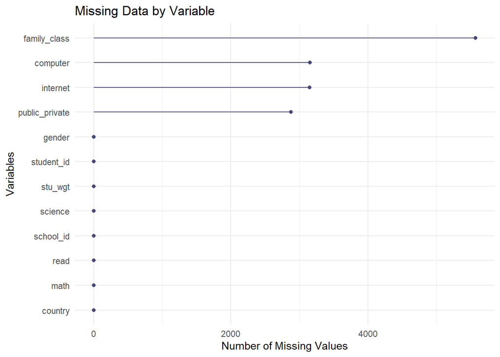

```r
library(naniar)

# Visualize missing data
gg_miss_var(updated_data) +
  labs(title = "Missing Data by Variable", x = "Variables", y = "Number of Missing Values")
```

```r
# Count missing data rows
total_rows <- nrow(updated_data)
rows_with_na <- nrow(updated_data %>% filter(!complete.cases(.)))
proportion_removed <- rows_with_na / total_rows
cat("Total rows:", total_rows, "\nRows with NA:", rows_with_na,
    "\nProportion removed:", round(proportion_removed * 100, 2), "%\n")
```

```
## Total rows: 50744
## Rows with NA: 8295
## Proportion removed: 16.35 %
```

Filter out rows with NA values.

```r
# Remove rows with NA
cleaned_data <- updated_data %>%
  drop_na()

# Summary of remaining rows
remaining_rows <- nrow(cleaned_data)
cat("Remaining rows after removing NA:", remaining_rows, "\n")
```

```
## Remaining rows after removing NA: 42449
```

Create a bar plot to compare the number of rows before and after removing NA.

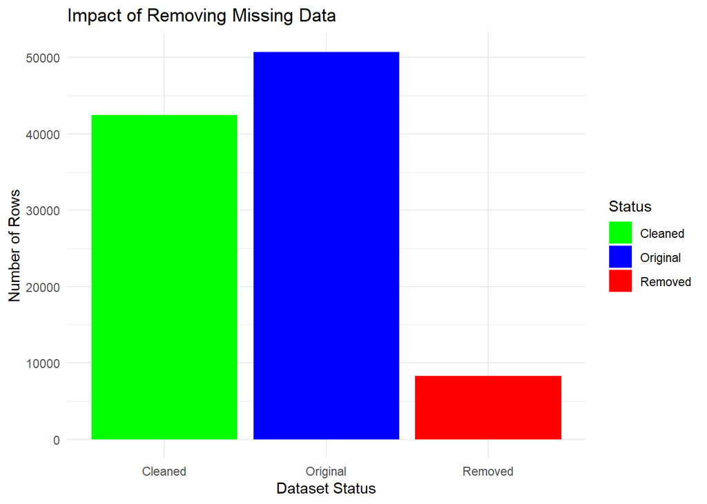

```r
library(ggplot2)

# Data for visualization
removal_summary <- tibble(
  Status = c("Original", "Removed", "Cleaned"),
  Count = c(total_rows, rows_with_na, remaining_rows)
)

# Plot
ggplot(removal_summary, aes(x = Status, y = Count, fill = Status)) +
  geom_bar(stat = "identity") +
  labs(
    title = "Impact of Removing Missing Data",
    x = "Dataset Status",
    y = "Number of Rows"
  ) +
  scale_fill_manual(values = c("Original" = "blue", "Removed" = "red", "Cleaned" = "green")) +
  theme_minimal()
```

## Analyze Characteristics of Removed Data

Investigate whether the rows with missing values have specific patterns or differ from the retained data.

```r
# Separate removed and retained data
removed_data <- updated_data %>% filter(!complete.cases(.))
retained_data <- updated_data %>% filter(complete.cases(.))

# Compare distributions of key variables
compare_summary <- bind_rows(
  removed_data %>% mutate(status = "Removed"),
  retained_data %>% mutate(status = "Retained")
) %>%
  group_by(status) %>%
  summarize(
    avg_math = mean(math, na.rm = TRUE),
    avg_read = mean(read, na.rm = TRUE),
    avg_science = mean(science, na.rm = TRUE),
    total = n()
  )

print(compare_summary)
```

```
## # A tibble: 2 × 5
##   status   avg_math avg_read avg_science total
##   <chr>       <dbl>    <dbl>       <dbl> <int>
## 1 Removed      473.     474.        476.  8295
## 2 Retained     503.     511.        509. 42449
```

Removed: 8,295 rows with missing data. Retained: 42,449 rows with complete data. Interpretation: Around 16.35% of the total data was removed, which is substantial but not overly significant if the remaining data is representative.

1. Interperation: Students with missing data tend to have lower scores across all subjects. This may indicate that missingness is not random (e.g., related to socioeconomic status or school type), which could introduce bias if not properly addressed.
2. Weaknesses:

Potential Bias: If the missing data is associated with lower-performing students, removing these rows may overestimate overall averages and lead to biased conclusions. This highlights a potential “data not missing at random” (NMAR) issue.

Consideration of Missingness: Missingness may relate to systematic factors such as resource availability, school type, or socioeconomic factors. Justify removal by emphasizing that imputing values could introduce noise or bias, depending on the imputation method.

Model Building: Acknowledge that the cleaned dataset may skew towards higher-performing students. Use this insight to inform model selection or consider methods that adjust for missingness.

3. Justification:

Argue that removing rows with missing data ensures analytical consistency, as models often require complete cases. Emphasize that while the removed data differs slightly, the retained data is still sufficiently large for robust analysis.

4. Next Steps:

If possible, explore imputation methods to handle missing values (e.g., mean imputation, multiple imputation, or regression-based methods). Alternatively, include an analysis of missingness patterns as part of your report to address potential bias transparently.

```r
head(cleaned_data)
```

```
## # A tibble: 6 × 12
##   country school_id student_id gender computer internet  math  read science
##   <fct>   <fct>     <fct>      <fct>  <fct>    <fct>    <dbl> <dbl>   <dbl>
## 1 AUS     3600002   3600210    female yes      yes       541.  611.    530.
## 2 AUS     3600002   3602562    female yes      yes       431.  469.    454.
## 3 AUS     3600002   3602765    male   yes      yes       617.  642.    659.
## 4 AUS     3600002   3603797    female yes      yes       359.  449.    401.
## 5 AUS     3600002   3606990    female yes      yes       475.  440.    443.
## 6 AUS     3600002   3608618    female yes      yes       436.  498.    420.
## # ℹ 3 more variables: stu_wgt <dbl>, public_private <fct>, family_class <chr>
```

```r
saveRDS(cleaned_data,file = "./data/cleaned/cleaned_data.Rds")
```